# Módulo 7

Deep Learning

Eloy Alvarado Narváez

eloy.alvarado@usm.cl

Universidad Técnica Federico Santa María

Esteban Salgado Valenzuela

Universidad Técnica Federico Santa María

14 de diciembre de 2024

# Deep Learning

## Redes Neuronales

Una red neuronal artificial, ANN por sus siglas en inglés artificial neural network modelan la relación entre un conjunto de *señales* de entrada y una *señal de salida* usando un modelo derivado desde nuestro entendimiento de cómo funciona un cerebro biológico ante estímulos externos.

Tal como un cerebro usa una red de células interconectadas llamadas neuronas, una red neuronal usa una red de neuronas artificiales o nodos para resolver problemas de aprendizaje.

## Red Neuronal de Capa Única

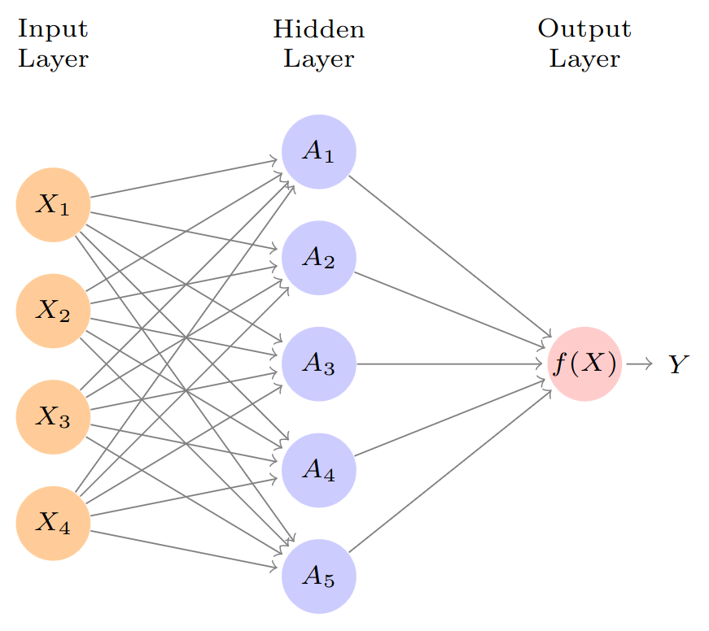

$$\begin{align*}
f(X) &= \beta_0 + \sum_{k=1}^K \beta_k h_k(X) \\
&= \beta_0 + \sum_{k=1}^K \beta_k g\left(w_{k0} + \sum_{j=1}^p w_{kj} X_j\right).
\end{align*}$$

## Red Neuronal de Capa Única

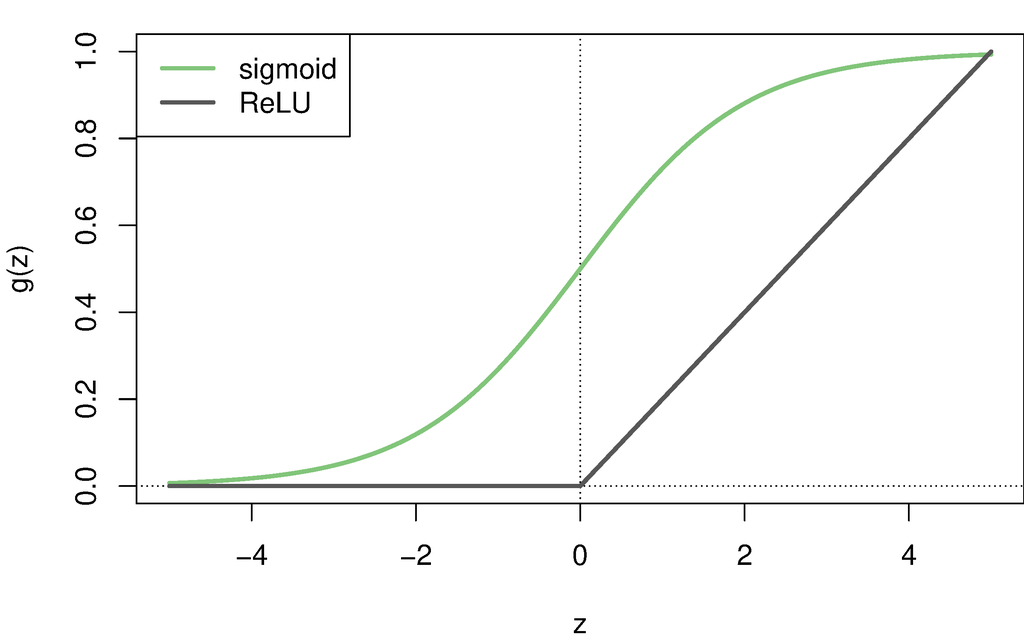

- $A_k = h_k(X) = g\left(w_{k0} + \sum_{j=1}^p w_{kj} X_j\right)$ se denominan activaciones en la capa oculta.
- $g(z)$ se denomina función de activación. Las más populares son la función sigmoide y la rectificada lineal (ReLU), mostradas en la figura.
- Las funciones de activación en las capas ocultas suelen ser no lineales, de lo contrario el modelo colapsaría a un modelo lineal.
- Por lo tanto, las activaciones son como características derivadas: transformaciones no lineales de combinaciones lineales de las características.
- El modelo se ajusta minimizando $\sum_{i=1}^n (y_i - f(x_i))^2$.

## Ejemplo: Dígitos MNIST

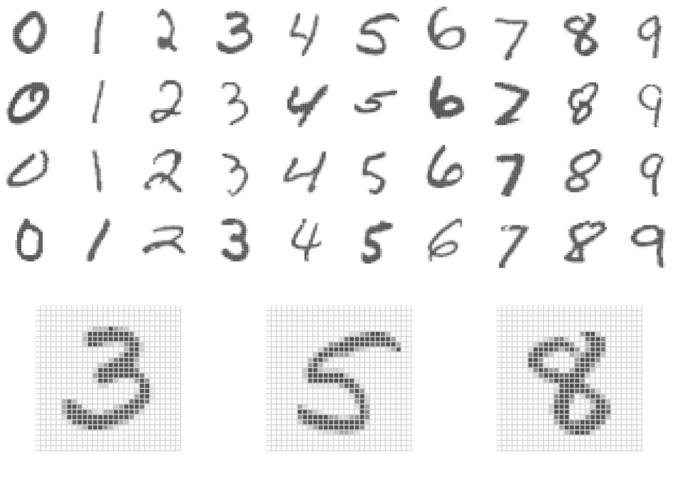

- Dígitos escritos a mano, en escala de grises de tamaño $28 \times 28$.
- $60.000$ imágenes de entrenamiento, $10.000$ imágenes de prueba.
- Las características son los 784 valores de píxeles en escala de grises $\in (0, 255)$
- Las etiquetas corresponden a las clases de dígitos del 0 al 9.

Objetivo: construir un clasificador para predecir la clase de la imagen.

## Ejemplo: Dígitos MNIST

Construimos una red neuronal de dos capas con:

- 256 unidades en la primera capa,
- 128 unidades en la segunda capa,
- 10 unidades en la capa de salida.
- Junto con los interceptos (*sesgos*), hay un total de 235,146 parámetros (*pesos*).

## Ejemplo: Dígitos MNIST

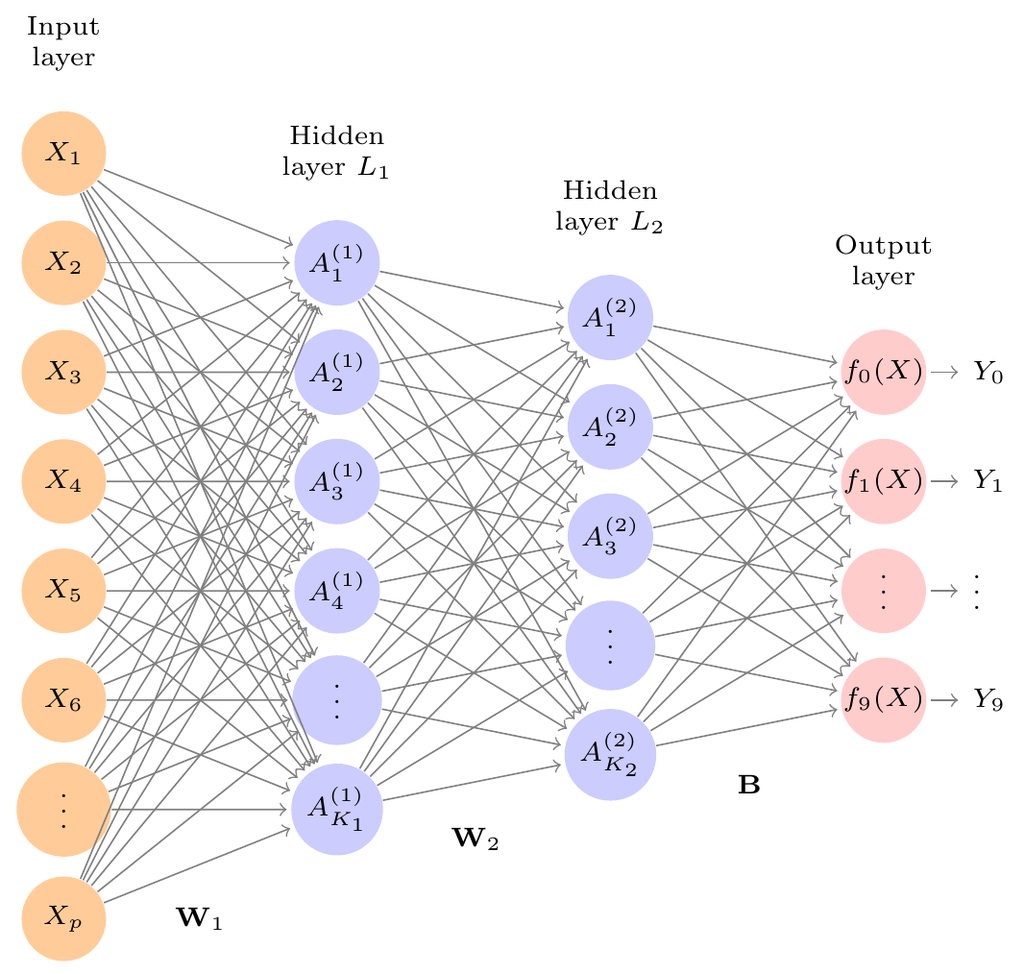

## Ejemplo: Dígitos MNIST

### Detalles de la Capa de Salida

- Sea $Z_m = \beta_{m0} + \sum_{\ell=1}^{K_2} \beta_{m\ell} A_{\ell}^{(2)}$, donde $m = 0, 1, \dots, 9$ son 10 combinaciones lineales de activaciones en la segunda capa.
- La función de activación de salida codifica la función *softmax*:

$$f_m(X) = \mathbb{P}(Y = m \mid X) = \frac{e^{Z_m}}{\sum_{\ell=0}^9 e^{Z_\ell}}.$$

- Ajustamos el modelo minimizando la verosimilitud negativa multinomial (o entropía cruzada):

$$- \sum_{i=1}^n \sum_{m=0}^9 y_{im} \log(f_m(x_i)).$$

- $y_{im}$ es 1 si la clase verdadera para la observación $i$ es $m$, de lo contrario es 0 — es decir, one-hot encoded.

## Resultados

| **Método** | **Error de prueba** |
| --- | --- |
| Red neuronal + Regularización Ridge | **2.3%** |
| Red neuroral + Regularización Dropout | **1.8%** |
| Regresión logística multinomial | **7.2%** |
| Análisis discriminante lineal | **12.7%** |

- Al tener tantos parámetros, la regularización es esencial.
- Problema ampliamente estudiado: las mejores tasas reportadas son $< 0.5\%$.
- La tasa de error humana se reporta alrededor de $0.2\%$, o $20$ de las $10.000$ imágenes de prueba.

## Redes Neuronales Convolucionales (CNN)

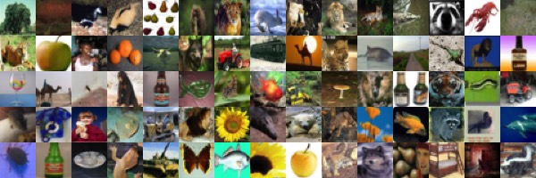

- Las imágenes corresponder al conjunto de datos `CIFAR100`.
- Imágenes a color de $32 \times 32$ de $100$ clases distintas.
- $50.000$ imágenes de entrenamiento, $10.000$ imágenes de prueba.
- Cada imagen es un arreglo tridimensional o un *mapa de características*: una matriz de $32 \times 32 \times 3$ compuesta por números de 8 bits.
- La última dimensión representa los tres canales de color: rojo, verde y azul.

[figure not shown]